# Bayesian spatio-temporal modelling of anchovy abundance through the SPDE approach

February 19, 2019

\[\renewcommand{\vec}[1]{\boldsymbol{#1}}\]

## Peruvian anchoveta

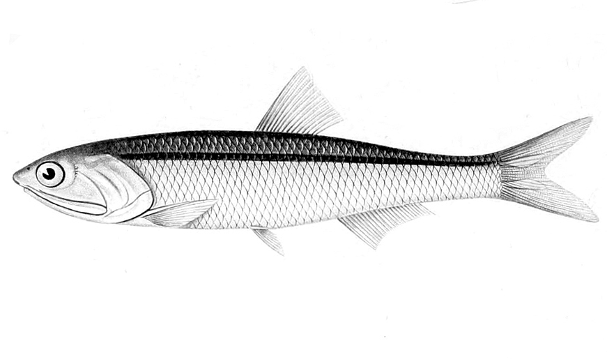

https://en.wikipedia.org/wiki/Peruvian_anchoveta

## Fishery

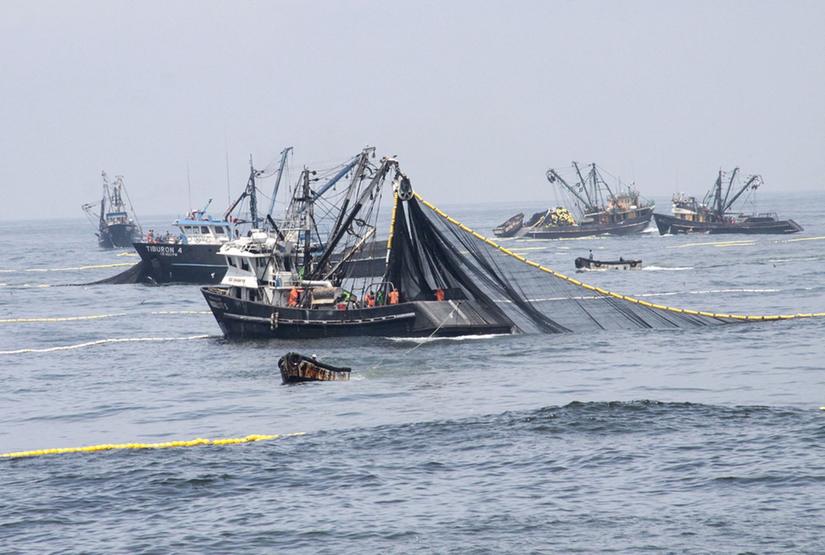

Photo credit: Angencia Andina

## Data

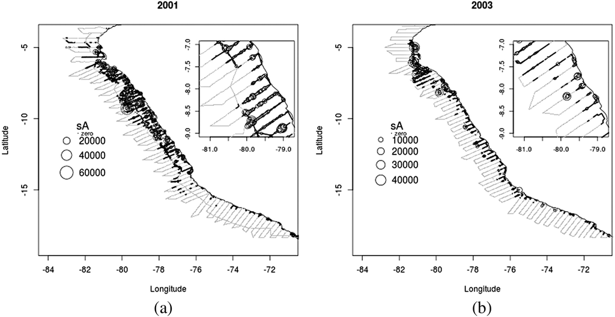

Survey observations for 2001 and 2003

## Need to account for the zeros

Use two latent Gaussian fields with linear predictors

\[\begin{aligned} \eta^{(1)}(s_i, t) &= \vec{Z}^{(1)}(s_i,t)\vec{\beta}^{(1)} + f^{(1)}(t) + f_s^{(1)}(s_i, t) + f_{st}^{(1)}(s_i,t)\\ \eta^{(2)}(s_i, t) &= \vec{Z}^{(2)}(s_i,t)\vec{\beta}^{(2)} + f^{(2)}(t) + f_s^{(2)}(s_i, t) + f_{st}^{(2)}(s_i,t) \end{aligned}\]

And a delta-gamma density

\[\begin{aligned} y(s_i,t) = 0 &\sim \operatorname{Bernoulli}\left(\operatorname{logit}^{-1}\left(\eta^{(1)}(s_i,t)\right)\right)\\ y(s_i,t) \mid y(s_i,t) > 0 &\sim \operatorname{Gamma}\left(\phi, \frac{\phi}{\exp\left(\eta^{(2)}(s_i,t)\right)}\right) \end{aligned}\]

## Covariates

In all models:

- **CD**: Distance to coast
- **Depth**
- **SST**: Sea surface temperature

In absence/presence component:

- Quadratic effect of **latitude**

In the S3 & ST3 models:

- 3-year **periodic components; \(\sin(2\pi t / 3)\) and \(\cos(2 \pi t / 3)\)**;

## Temporal effects

Models **S2** and **ST2**, AR(1):

\[\begin{aligned} f(1) &\sim \operatorname{Normal}\left(0, \frac{1}{\tau_{ar}\left(1 - b^{2}\right)}\right)\\ f(t) &= b \cdot f(t-1) + \epsilon_{ar}(t)\\ \epsilon_{ar}(t) &\sim \operatorname{Normal}\left(0, \frac{1}{\tau_{ar}}\right) \quad t = 2,\dots,T \end{aligned}\]

## Temporal effects

Models **S4** and **ST4**, RW(2):

\[\begin{aligned} f(t) &= 2 \cdot f(t + 1) - f(t + 2) + \epsilon_{rw2}(t)\\ \epsilon_{rw2}(t) &\sim \operatorname{Normal}\left(0, \frac{1}{\tau_{rw2}}\right) \quad t = 1,\dots,T-2 \end{aligned}\]

## Spatial effects

A GRF

\[\vec{f}_s(\cdot,t) \stackrel{\text{iid}}{\sim} \operatorname{MVN}\left(\vec{0}, \vec{Q}_s^{-1}\right) \quad t = 1,\dots,T\]

where \(\vec{Q}_s\) is associated with the solution to

\[\left( \kappa^2 - \Delta \right)^{\alpha / 2}(\tau X(s)) = G(s), \quad s \in \mathbb{R}^n\]

through its weak solution \[\left[ \langle \phi_i,(\kappa^2 - \Delta)^{\alpha/2} \tilde{X}\rangle_\Omega\right] \stackrel{D}{=} \left[\langle \phi_i,G\rangle\right]\]

approximating a Matérn covariance with \(\nu = 1\).

## SPDE Mesh

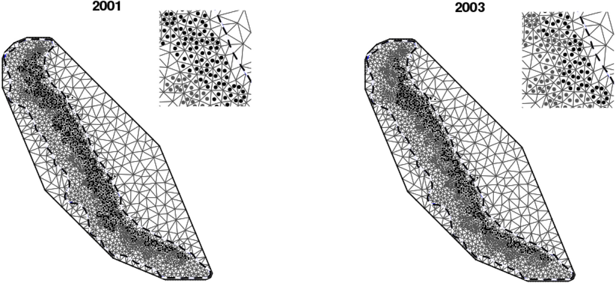

Fig. 2, 1147 nodes

## Spatiotemporal effects

An AR(1) process on the GRF

\[\begin{aligned} \vec{f}_{st}(\cdot, 1) &\sim \operatorname{MVN}\left(\vec{0}, \frac{1}{\left(1 - a^{2}\right)}\vec{Q}_w^{-1}\right)\\ \vec{f}_{st}(\cdot,t) &= a \cdot \vec{f}_{st}(\cdot,t - 1) + \vec{w}(\cdot, t)\\ \vec{w}(\cdot, t) &\stackrel{\text{iid}}{\sim} \operatorname{MVN}\left(\vec{0}, \vec{Q}_w^{-1}\right) \quad t = 2,\dots,T \end{aligned}\]

## Structured effects

| Model | S1 | S2 | S3 | S4 | ST1 | ST2 | ST3 | ST4 | S-ST |
| --- | --- | --- | --- | --- | --- | --- | --- | --- | --- |
| Temporal |  | AR(1) | [per] | RW(2) |  | AR(1) | [per] | RW(2) |  |
| Spatial | × | × | × | × |  |  |  |  | × |
| Spatiotemporal |  |  |  |  | × | × | × | × | × |

## Covariates on absence

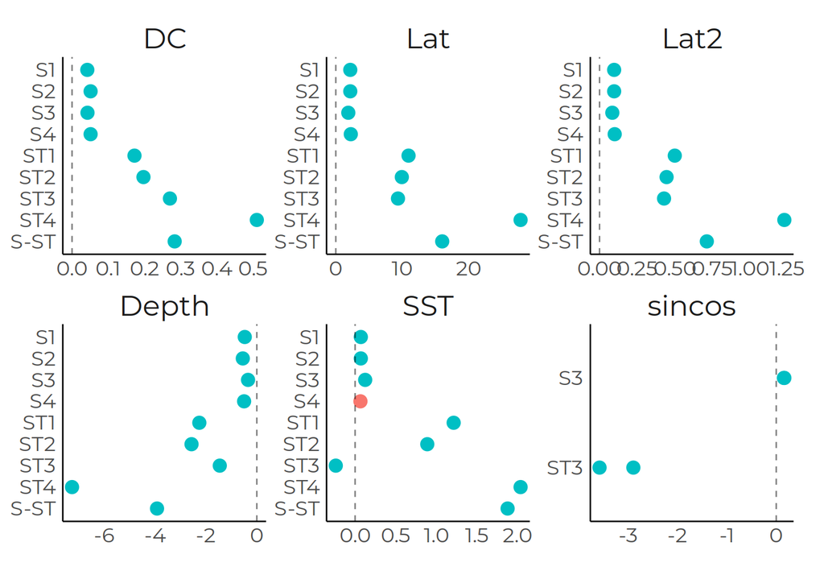

## Covariates on abundance

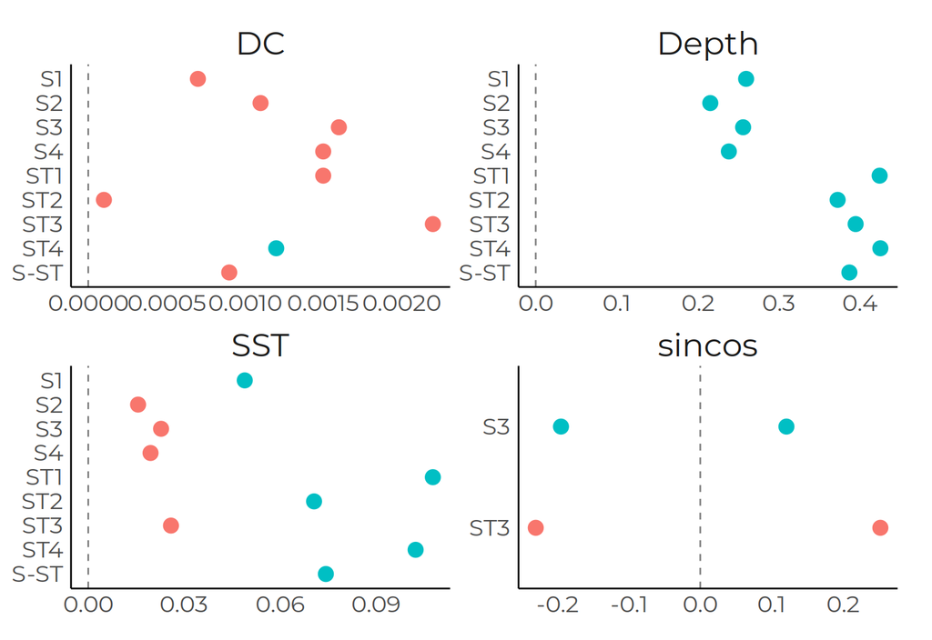

## Temporal processes

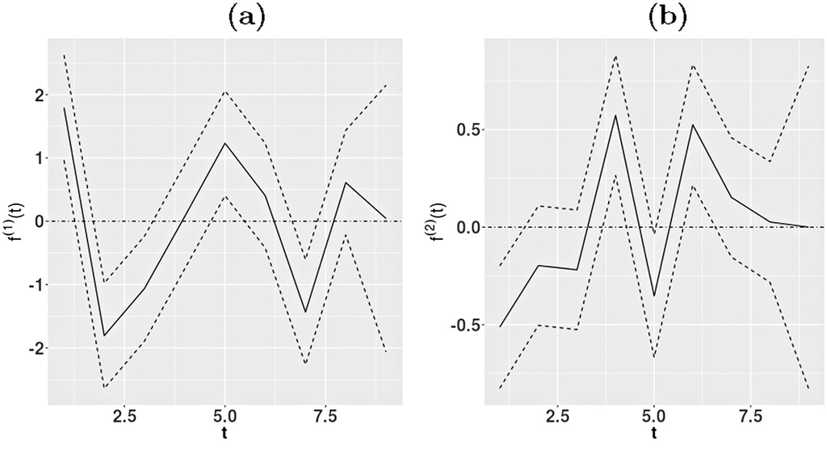

Fig. 3

## Temporal processes

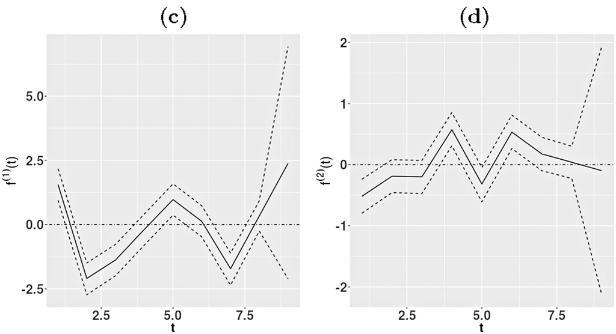

Fig. 3

## Model selection

|  | S1 | S2 | S3 | S4 | ST1 | ST2 | ST3 | ST4 | S-ST |
| --- | --- | --- | --- | --- | --- | --- | --- | --- | --- |
| EAR | 85.3 | 88.1 | 85.0 | 88.1 | **99.6** | **99.6** | **99.8** | **99.7** | **99.81** |
| WAIC | 135e3 | 144e3 | 132e3 | 158e3 | **58e3** | 1.30e6 | 1.22e6 | **59e3** | **51e3** |
| LPML | -223e3 | -202e3 | -224e3 | -183e3 | **-33e3** | -574e3 | -561e3 | **-34e3** | **-26e3** |
| RMSEE | 1388 | 1379 | 1329 | 1325 | **429** | **459** | 600 | **450** | **465** |
| RMSPE | **1071** | **1061** | **1099** | **1069** | **1091.5** | 2356 | 3962 | 1189 | 1295 |
| Time | 49m | 3h | 50m | 2h | 3d | 4d21h | 3d3h | 4d13h | 7d |

## Spatial fields

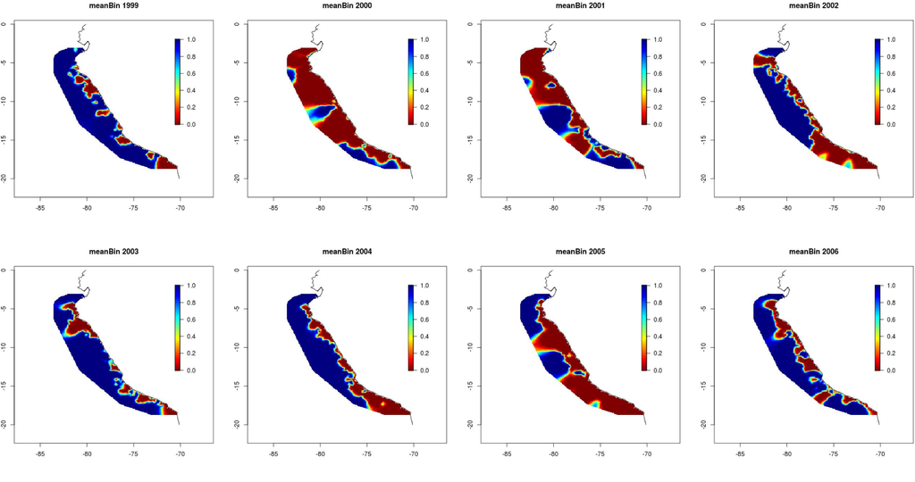

## Spatial fields

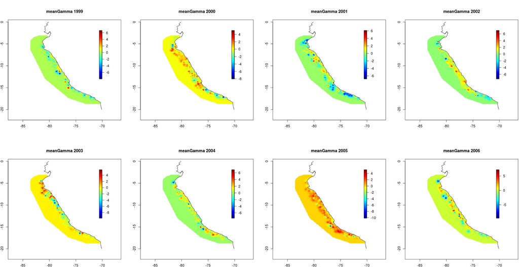

Fig 4: Posterior mean abundance

## Predicting the future

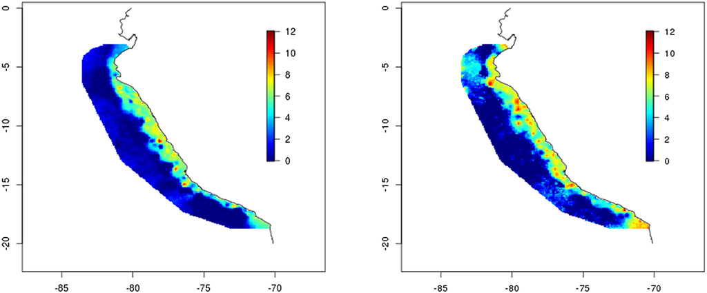

Fig. 7: Log-abundance, predicted on left, fitted on right

## Thanks!

### This paper:

- Quiroz, Zaida C. and Marcus O. Prates. 2018. Bayesian spatio-temporal modelling of anchovy abundance through the SPDE approach.*Spatial Statistics* 28, 236-256. https://www.sciencedirect.com/science/article/pii/S2211675317302816#b6

## Thanks!

### Related work:

- Lindgren et al. 2011. An explicit link between Gaussian fields and Gaussian Markov random fields. *J. R. Stat. Soc. Ser. B Stat. Methodol.*, 73 (4) https://doi.org/10.1111/j.1467-9868.2011.00777.x
- Cao et al. 2017. Spatiotemporal index standardization improves the stock assessment of northern shrimp in the Gulf of Maine. Can. J. Fish. Aquat. Sci. 74. https://doi.org/10.1139/cjfas-2016-0137
- Thorson, 2017. Three problems with the conventional delta-model for biomass sampling data, and a computationally efficient alternative. Can. J. Fish. Aquat. Sci. 75 https://doi.org/10.1139/cjfas-2017-0266